# Project 1: Wrangling, Exploration, Visualization

SDS322E

## Data Wrangling, Exploration, Visualization

### John Gutierrez JGG2649

#### Introduction

A couple weeks ago I finished reading *Moneyball*, by Michael Lewis. A book largely about the 2002 season of Oakland A’s, a baseball team in the MLB. A’s General Manager, Billy Beane, decided that the people in charge of baseball teams were not effectively leveraging statistics to run their baseball teams efficiently.

One of Beane’s core theories was that baseball teams were critically undervaluing what’s called *On-Base Percentage* (OBP). On-Base Percentage, simply put, is the proportion of batters that get on base. It does not matter how they get on base (they could be walked, hit a single, hit a home run, be hit by the pitch, etc.), just that they do not get out. Higher OBP leads to fewer outs which leads to scoring more runs which leads to winning more games. Sounds simple right? Billy Beane thought so, but he thought that other managers didn’t understand it that way.

Despite being one of the poorer team’s in the MLB, the Oakland A’s in the early 2000’s saw great success due to their leveraging of statistics and finding players with, among other traits, great OBP *for their price*. The A’s were just as successful as the Yankees while paying their players half as much.

This led me to want to analyze data on modern OBP and salaries and compare that to how successful teams were in their seasons. Are all teams allocating their money efficiently, or are some big-money teams still getting outplayed? All ranking and batting data is from Baseball-Reference.com and salary data is from spotrac.com.

```r
library(tidyverse)

payroll2020 <- read_csv("2020payroll.csv")
payroll2021 <- read_csv("2021payroll.csv")
rank2020 <- read_csv("2020rankings.csv")
rank2021 <- read_csv("2021rankings.csv")
batting2021 <- read_csv("2021batting.csv")
batting2020 <- read_csv("2020batting.csv")
```

#### Tidying: Reshaping

I decided to do some reshaping in the summary statistics section, since my data is already tidy.

#### Joining/Merging

```r
payroll <- payroll2020 %>% mutate(Year = 2020) %>% bind_rows(payroll2021 %>%
    mutate(Year = 2021))
rank <- rank2020 %>% mutate(Year = 2020) %>% slice(1:30) %>%
    bind_rows(rank2021 %>% mutate(Year = 2021) %>% slice(1:30))
batting <- batting2020 %>% mutate(Year = 2020) %>% slice(1:30) %>%
    bind_rows(batting2021 %>% mutate(Year = 2021) %>% slice(1:30))

nrow(batting) == nrow(rank) & nrow(rank) == nrow(payroll) & nrow(payroll) ==
    60
```

```
## [1] TRUE
```

Before we join, I’d like to combine my 6 data frames from two different years into 3 data frames with a new Year variable. We do so above with mutate and bind_rows. The slice is to remove the extraneous “League Average” data included in the data sets. Now we have 3 data frames with batting, rank, and payroll data for all 30 teams in years 2020 and 2021, for a total of 60 rows in each data frame. This means our “Primary Key”, if you will, is a combination of the Team and Year columns.

```r
c(setdiff(payroll$Team, batting$Tm), setdiff(batting$Tm, payroll$Team))
```

```
## character(0)
```

```r
df <- rank %>% full_join(batting, by = c("Tm", "Year")) %>% full_join(payroll,
    by = c(Tm = "Team", "Year"))
glimpse(df)  #Just so y'all have an idea of what my dataset looks like
```

```
## Rows: 60
## Columns: 66
## $ Rk        <dbl> 1, 2, 3, 4, 5, 6, 7, 8, 9, 10, 11, 12, 13, 14, 15, 16, 17, …
## $ Tm        <chr> "Los Angeles Dodgers", "Tampa Bay Rays", "San Diego Padres"…
## $ W         <dbl> 43, 40, 37, 36, 36, 35, 35, 35, 34, 33, 32, 30, 31, 31, 29,…
## $ L         <dbl> 17, 20, 23, 24, 24, 25, 25, 25, 26, 27, 28, 28, 29, 29, 31,…
## $ `W-L%`    <dbl> 0.717, 0.667, 0.617, 0.600, 0.600, 0.583, 0.583, 0.583, 0.5…
## $ R.x       <dbl> 5.8, 4.8, 5.4, 4.5, 4.6, 5.8, 5.1, 4.1, 4.4, 5.3, 5.0, 4.1,…
## $ RA        <dbl> 3.6, 3.8, 4.0, 3.6, 3.9, 4.8, 4.1, 3.5, 4.0, 4.5, 5.2, 3.9,…
## $ Rdiff     <dbl> 2.3, 1.0, 1.4, 0.9, 0.7, 1.0, 1.0, 0.7, 0.4, 0.8, -0.2, 0.2…
## $ SOS       <dbl> -0.1, -0.1, 0.0, 0.0, -0.4, -0.2, 0.0, 0.0, -0.2, -0.1, 0.0…
## $ SRS       <dbl> 2.2, 0.9, 1.4, 0.9, 0.3, 0.8, 1.0, 0.6, 0.3, 0.7, -0.1, 0.0…
## $ pythWL    <chr> "43-17", "36-24", "38-22", "36-24", "35-25", "35-25", "36-2…
## $ Luck      <dbl> 0, 4, -1, 0, 1, 0, -1, 0, 1, -1, 3, 0, 5, 1, -1, -1, 1, -2,…
## $ vEast     <chr> "0-0", "27-13", "0-0", "0-0", "0-0", "24-16", "0-0", "0-0",…
```

[output cut: 53 more lines]

#### Wrangling

There’s an obvious problem that all the salary numbers are character type and include commas and dollar signs. Let’s change that with str_remove_all and as.numeric, applied with mutate_at.

```r
money_to_num <- function(x) as.numeric(str_remove_all(x, "[$,]"))
df <- df %>% mutate_at(vars(Active:Total), money_to_num)
df %>% select(Tm, Active:Total) %>% head
```

```
## # A tibble: 6 x 7
##   Tm                    Active      IR Retained   Buried Suspended     Total
##   <chr>                  <dbl>   <dbl>    <dbl>    <dbl>     <dbl>     <dbl>
## 1 Los Angeles Dodgers 77165961  493889 16917530 11339500        NA 107917397
## 2 Tampa Bay Rays      21769463 1958020  2086951  9537125        NA  28290689
## 3 San Diego Padres    54293958 3531020 14471215  6086600        NA  73097954
## 4 Minnesota Twins     45057558 6876058  7313300  6669000        NA  55679689
## 5 Oakland Athletics   35283875  902038   113148  3957000        NA  36720178
## 6 Atlanta Braves      50458292 7255497  1000284 17610000        NA  63561931
```

To make a new variable that’s at least a function of one other variable, let’s make a variable that’s “OBP per million dollars”, and go ahead and see which teams are paying the least for their OBP averaged over both years, as well as their average finishing rank.

```r
df <- df %>% mutate(OBPdollars = OBP/(Total/1e+06))
df %>% group_by(Tm) %>% summarize(avg = mean(OBPdollars), mean(Rk)) %>%
    arrange(desc(avg)) %>% slice(1:10)
```

```
## # A tibble: 10 x 3
##    Tm                     avg `mean(Rk)`
##    <chr>                <dbl>      <dbl>
##  1 Baltimore Orioles  0.00966       27.5
##  2 Pittsburgh Pirates 0.00845       28.5
##  3 Tampa Bay Rays     0.00806        2.5
##  4 Miami Marlins      0.00762       19
##  5 Cleveland Indians  0.00705       12
##  6 Kansas City Royals 0.00621       22
##  7 Oakland Athletics  0.00615        9
##  8 Milwaukee Brewers  0.00540       11
##  9 Detroit Tigers     0.00529       23
## 10 Seattle Mariners   0.00491       15
```

Including the average rank is important because, as you can see, even though the Orioles have the best OBP salary efficiency, they don’t perform very well, probably because their bankroll and OBP are both low. The Rays, on the other hand, stick out like a sore thumb. We also spot the Athletics, the notoriously thrifty team studied in *Moneyball*. Below are some summary statistics on some of the more interesting variables.

```r
library(kableExtra)
countNA <- function(z)sum(is.na(z))
df %>% mutate(`Salary($M)`=Total/1000000) %>%
  summarize_at(vars(W, `W-L%`, RBI, OBP, `Salary($M)`),
                    .funs=lst(mean, sd, var, min, max, n_distinct, countNA)) %>%
  pivot_longer(cols=everything()) %>% separate(name, into=c("stat", "name"), sep="_") %>%
  pivot_wider(names_from="name",values_from="value") %>%
  rename(n_distinct=n) %>%
  kable(digits = 3, align = 'c', col.names=str_to_title(names(.)))
```

| Stat | Mean | Sd | Var | Min | Max | N_distinct | Countna |
| --- | --- | --- | --- | --- | --- | --- | --- |
| W | 55.450 | 27.937 | 780.489 | 19.000 | 107.000 | 42 | 0 |
| W-L% | 0.500 | 0.090 | 0.008 | 0.317 | 0.717 | 41 | 0 |
| RBI | 482.850 | 225.123 | 50680.536 | 204.000 | 834.000 | 54 | 0 |
| OBP | 0.319 | 0.014 | 0.000 | 0.284 | 0.349 | 37 | 0 |
| Salary($M) | 95.844 | 54.475 | 2967.557 | 23.479 | 267.201 | 60 | 0 |

```r
df %>% mutate(`Salary($M)`=Total/1000000) %>%
  group_by(Tm) %>%
  summarize_at(vars(W, `W-L%`, RBI, OBP, `Salary($M)`),
                    .funs=lst(mean, sd, var, min, max, n_distinct, countNA)) %>%
  pivot_longer(cols=2:36) %>% separate(name, into=c("stat", "name"), sep="_") %>%
  pivot_wider(names_from="name",values_from="value") %>%
  rename(n_distinct=n) %>%
  filter(Tm=="Oakland Athletics") %>% #Filtered so that I'm not listing 150 rows
  kable(digits = 3, align = 'c', col.names=str_to_title(names(.)))
```

| Tm | Stat | Mean | Sd | Var | Min | Max | N_distinct | Countna |
| --- | --- | --- | --- | --- | --- | --- | --- | --- |
| Oakland Athletics | W | 61.000 | 35.355 | 1250.000 | 36.000 | 86.000 | 2 | 0 |
| Oakland Athletics | W-L% | 0.566 | 0.049 | 0.002 | 0.531 | 0.600 | 2 | 0 |
| Oakland Athletics | RBI | 481.000 | 306.884 | 94178.000 | 264.000 | 698.000 | 2 | 0 |
| Oakland Athletics | OBP | 0.319 | 0.004 | 0.000 | 0.316 | 0.322 | 2 | 0 |
| Oakland Athletics | Salary($M) | 63.185 | 37.427 | 1400.815 | 36.720 | 89.651 | 2 | 0 |

#### Visualizing

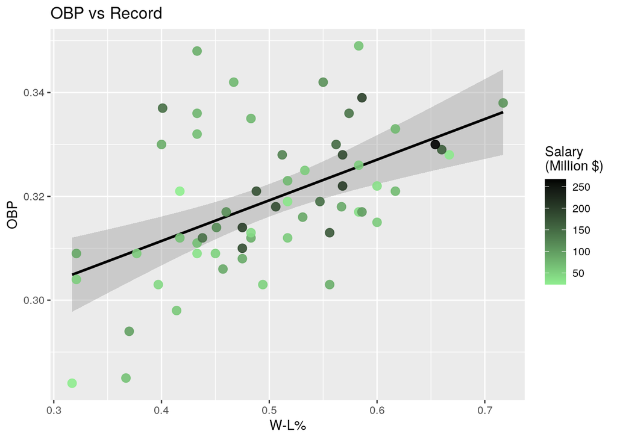

```r
df <- df %>% mutate(Year = as.factor(Year), Salary = Total/1e+06)
df %>% ggplot(aes(x = `W-L%`, y = OBP)) + geom_smooth(method = "lm",
    color = "Black") + geom_point(aes(color = Salary), size = 3,
    alpha = 0.9) + scale_color_gradient(name = "Salary\n(Million $)",
    low = "light green", high = "black") + ggtitle("OBP vs Record")
```

First it seems appropriate to see if teams with good OBP actually win games. Maybe a bit obvious, but we do see a good relationship between OBP and overall season record.

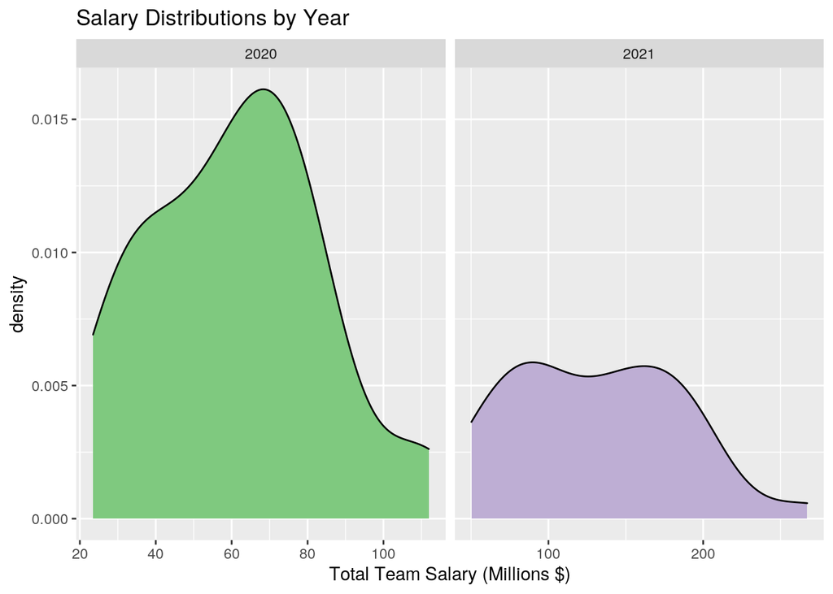

```r
df %>% ggplot() + geom_density(aes(x = Salary, fill = Year)) +
    facet_grid(. ~ Year, scales = "free_x") + xlab("Total Team Salary (Millions $)") +
    scale_fill_brewer(palette = "Accent") + theme(legend.position = "none") +
    ggtitle("Salary Distributions by Year")
```

What do salary distributions looks like in the MLB anyways? 2020 was kind of a weird year because of the pandemic, so it might be a bit of an outlier compared to most other years.

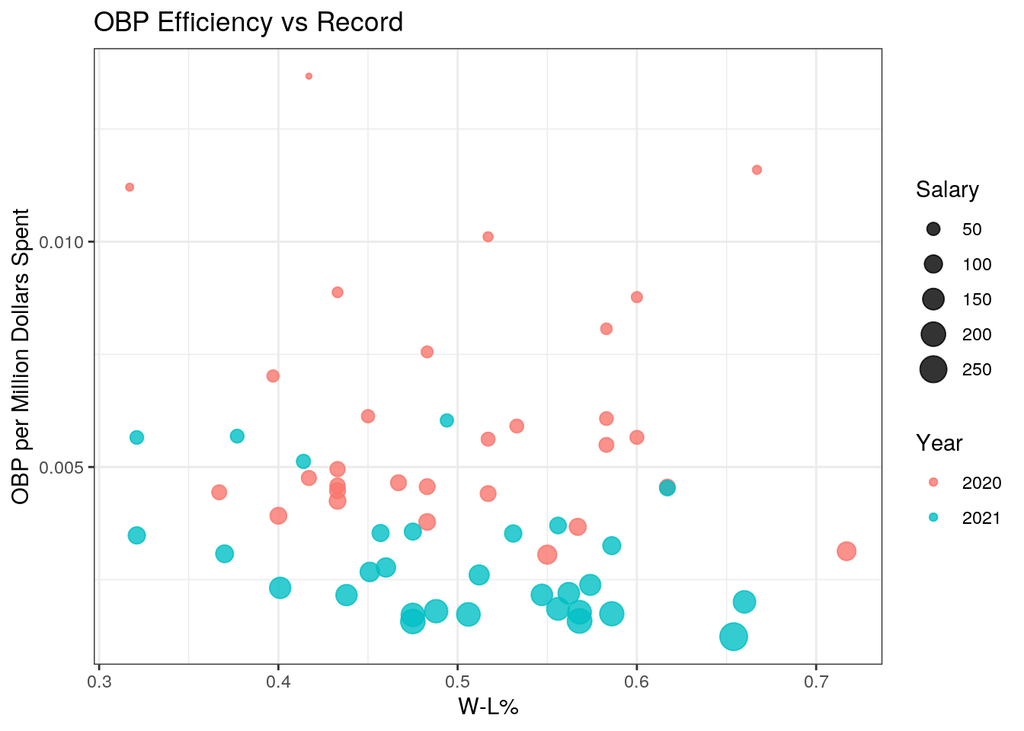

```r
df %>% ggplot() + geom_point(aes(x = `W-L%`, y = OBPdollars,
    color = Year, size = Salary), alpha = 0.8) + ylab("OBP per Million Dollars Spent") +
    ggtitle("OBP Efficiency vs Record") + theme_bw()
```

Do teams spending less for their OBP end up with more wins? Well… not necessarily. In fact, it seems like there’s no relationship between the two. Perhaps this is because there’s more to winning a baseball game than just OBP. Perhaps teams have become more efficient in recent years, so even the ones who are relatively less efficient are spending their cash wisely enough to win games.